# Wine Quality Feature Selection & Prediction Project

## Test for Independence of Errors

### graph

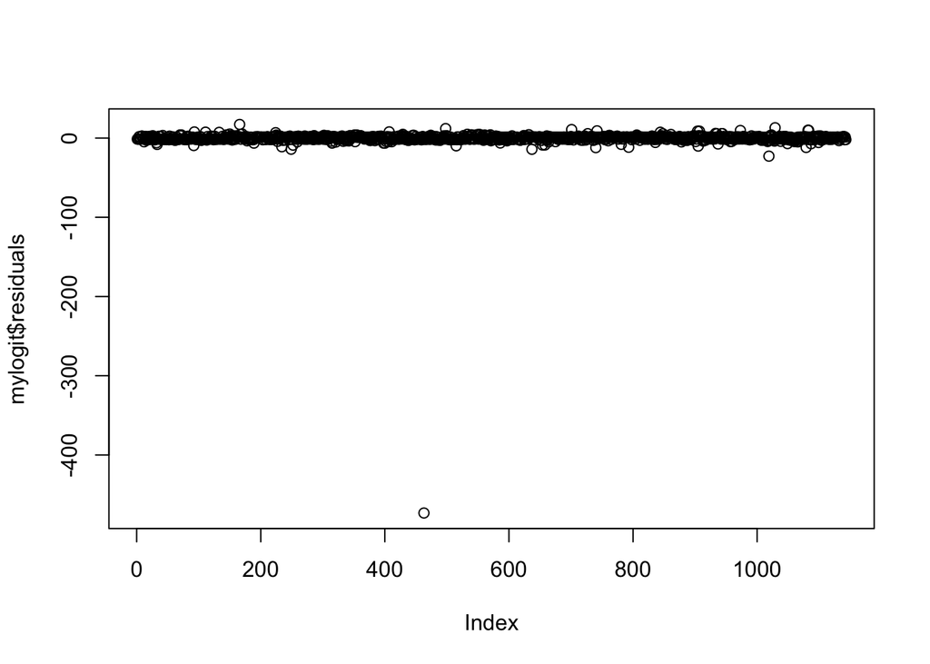

```r
plot(mylogit$residuals)
```

We are looking for pretty even distribution of points all the way across the x axis. We have that, so have met the assumption of independent errors.

### Durbin-Watson Test

Just for the sake of double checking for independence errors:

```r
dwtest(mylogit, alternative="two.sided")
```

```
##
##  Durbin-Watson test
##
## data:  mylogit
## DW = 1.8156, p-value = 0.001465
## alternative hypothesis: true autocorrelation is not 0
```

Output: Durbin-Watson test

data: mylogit DW = 1.8156, p-value = 0.001465 alternative hypothesis: true autocorrelation is not 0

## Screening for Outliers

```r
infl <- influence.measures(mylogit)
summary(infl)
```

```
## Potentially influential observations of
##   glm(formula = qualityR ~ fixed.acidity + volatile.acidity + citric.acid +      residual.sugar + chlorides + free.sulfur.dioxide + total.sulfur.dioxide +      density + pH + sulphates + alcohol, family = "binomial",      data = wine) :
##
##      dfb.1_ dfb.fxd. dfb.vlt. dfb.ctr. dfb.rsd. dfb.chlr dfb.fr.. dfb.tt..
## 12   -0.06   0.00    -0.10    -0.04    -0.03     0.17     0.01     0.05
## 14   -0.01  -0.04    -0.06    -0.02    -0.03     0.18     0.00     0.01
## 31   -0.03  -0.01    -0.06    -0.06    -0.01     0.14    -0.02     0.00
## 55   -0.01   0.00    -0.03     0.02     0.02     0.07     0.01    -0.06
## 60    0.00   0.00     0.00    -0.01     0.00    -0.03    -0.01     0.02
## 65    0.00   0.00     0.00    -0.01     0.00    -0.03    -0.01     0.02
## 76    0.00   0.02     0.02    -0.01     0.03    -0.21     0.01    -0.02
## 104   0.08   0.15    -0.09    -0.10     0.04    -0.32    -0.13     0.10
## 162   0.08   0.05     0.04    -0.01     0.03     0.06     0.02     0.01
## 166   0.07   0.04     0.13     0.05     0.04    -0.04    -0.02     0.00
## 171   0.05   0.08    -0.03    -0.04     0.02     0.01    -0.01     0.01
```

[output cut: 114 more lines]

None of the *db.1_* or *dffit* values are greater than 1, nor is *hat* greater than 0.3, so there is no evidence of outliers that need to be removed.